# Z(log) Transformation for Laboratory Measurements

# Introduction

The `zlog` package offers functions to transform laboratory measurements into standardised $z$ or $z(log)$-values as suggested in Hoffmann et al. (2017). Therefore the lower and upper reference limits are needed. If these are not known they could estimated from a given sample.

# Z or Z(log) Transformation

Hoffmann et al. (2017) define $z$ as follows:

$$z = (x - (limits_1 + limits_2 )/2) * 3.92/(limits_2 - limits_1)$$

Consequently the $z(log)$ is defined as:

$$zlog = (\log(x) - (\log(limits_1) + \log(limits_2))/2) * 3.92/(\log(limits_2) - \log(limits_1))$$

Where $x$ is the measured laboratory value and $limits_1$ and $limits_2$ are the lower and upper reference limit, respectively.

Example data and reference limits are taken from Hoffmann et al. (2017), Table 2.

```r
library("zlog")

albumin <- c(42, 34, 38, 43, 50, 42, 27, 31, 24)
z(albumin, limits = c(35, 52))
```

```
## [1] -0.345876 -2.190548 -1.268212 -0.115292  1.498796 -0.345876 -3.804636
## [8] -2.882300 -4.496388
```

```r
zlog(albumin, limits = c(35, 52))
```

```
## [1] -0.15472223 -2.24698167 -1.14569028  0.07826303  1.57162335 -0.15472223
## [7] -4.52949253 -3.16160843 -5.69571148
```

# Inverse Z or Z(log) Transformation/Undo Transformation

```r
izlog(zlog(albumin, limits = c(35, 52)), limits = c(35, 52))
```

```
## [1] 42 34 38 43 50 42 27 31 24
```

# Z(log) Dependent Colour Gradient

Hoffmann et al. (2017) suggested a colour gradient to visualise laboratory measurements for the user.

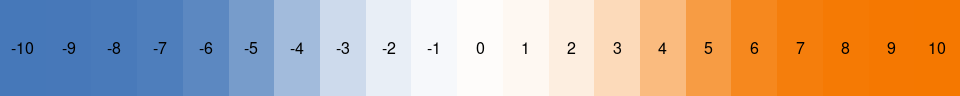

It could be used to highlight the values in a table:

Table reproduced from Hoffmann et al. (2017), Table 2, limits used: albumin 35-52 g/l, bilirubin 2-21 µmol/l.

| Category | albumin | zlog(albumin) | bilirubin | zlog(bilirubin) |
| --- | --- | --- | --- | --- |
| blood donor | 42 | -0.15 | 11 | 0.88 |
| blood donor | 34 | -2.25 | 9 | 0.55 |
| blood donor | 38 | -1.15 | 2 | -1.96 |
| hepatitis without cirrhosis | 43 | 0.08 | 5 | -0.43 |
| hepatitis without cirrhosis | 50 | 1.57 | 22 | 2.04 |
| hepatitis without cirrhosis | 42 | -0.15 | 42 | 3.12 |
| hepatitis with cirrhosis | 27 | -4.53 | 37 | 2.90 |
| hepatitis with cirrhosis | 31 | -3.16 | 200 | 5.72 |
| hepatitis with cirrhosis | 24 | -5.70 | 20 | 1.88 |

# Estimate Reference Limits

The `reference_limits` functions calculates the lower and upper 2.5 or 97.5 (or a user given probability) quantiles:

```r
reference_limits(albumin)
```

```
## lower upper
##  24.6  48.6
```

```r
reference_limits(albumin, probs = c(0.05, 0.95))
```

```
## lower upper
##  25.2  47.2
```

```r
exp(reference_limits(log(albumin)))
```

```
##    lower    upper
## 24.57207 48.51429
```

# Working with Reference Tables

Most laboratories use their own age- and sex-specific reference limits. The `lookup_limits` function could be used to find the correct reference limit.

```r
# toy example
reference <- data.frame(
    param = c("albumin", rep("bilirubin", 4)),
    age = c(0, 1, 2, 3, 7),     # days
    sex = "both",
    units = c("g/l", rep("µmol/l", 4)), # ignored
    lower = c(35, rep(NA, 4)),  # no real reference values
    upper = c(52, 5, 8, 13, 18) # no real reference values
)
knitr::kable(reference)
```

| param | age | sex | units | lower | upper |
| --- | --- | --- | --- | --- | --- |
| albumin | 0 | both | g/l | 35 | 52 |
| bilirubin | 1 | both | µmol/l | NA | 5 |
| bilirubin | 2 | both | µmol/l | NA | 8 |
| bilirubin | 3 | both | µmol/l | NA | 13 |
| bilirubin | 7 | both | µmol/l | NA | 18 |

```r
# lookup albumin reference values for 18 year old woman
lookup_limits(
    age = 18 * 365.25,
    sex = "female",
    table = reference[reference$param == "albumin",]
)
```

```
##         lower upper
## albumin    35    52
```

```r
# lookup albumin and bilirubin values for 18 year old woman
lookup_limits(
    age = 18 * 365.25,
    sex = "female",
    table = reference
)
```

```
##           lower upper
## albumin      35    52
## bilirubin    NA    18
```

```r
# lookup bilirubin reference values for infants
lookup_limits(
    age = 0:8,
    sex = rep(c("female", "male"), 5:4),
    table = reference[reference$param == "bilirubin",]
)
```

```
##           lower upper
## bilirubin    NA    NA
## bilirubin    NA     5
## bilirubin    NA     8
## bilirubin    NA    13
## bilirubin    NA    13
## bilirubin    NA    13
## bilirubin    NA    13
## bilirubin    NA    18
## bilirubin    NA    18
```

# Missing Reference Limits

Sometimes reference limits are not specified. That is often the case for biomarkers that are related to infection or cancer. Using zero as lower boundary results in skewed distributions (Hoffmann et al. 2017, fig. 7). Haeckel et al. (2015) suggested to set the lower reference limit to 15 % of the upper one.

```r
# use default fractions
set_missing_limits(reference)
```

```
##       param age  sex  units lower upper
## 1   albumin   0 both    g/l 35.00    52
## 2 bilirubin   1 both µmol/l  0.75     5
## 3 bilirubin   2 both µmol/l  1.20     8
## 4 bilirubin   3 both µmol/l  1.95    13
## 5 bilirubin   7 both µmol/l  2.70    18
```

```r
# set fractions manually
set_missing_limits(reference, fraction = c(0.2, 5))
```

```
##       param age  sex  units lower upper
## 1   albumin   0 both    g/l  35.0    52
## 2 bilirubin   1 both µmol/l   1.0     5
## 3 bilirubin   2 both µmol/l   1.6     8
## 4 bilirubin   3 both µmol/l   2.6    13
## 5 bilirubin   7 both µmol/l   3.6    18
```

# Impute Missing Laboratory Measurements

If laboratory measurements are missing they could be imputed using *“normal”* values from the reference table. Using the `"logmean"` (default) or `"mean"` reference value (default) will result in a $zlog$ or $z$-value of zero, respectively.

```r
x <- data.frame(
    age = c(40, 50),
    sex = c("female", "male"),
    albumin = c(42, NA)
)
x
```

```
##   age    sex albumin
## 1  40 female      42
## 2  50   male      NA
```

```r
z_df(impute_df(x, reference, method = "mean"), reference)
```

```
##   age    sex   albumin
## 1  40 female -0.345876
## 2  50   male  0.000000
```

```r
zlog_df(impute_df(x, reference), reference)
```

```
##   age    sex    albumin
## 1  40 female -0.1547222
## 2  50   male  0.0000000
```

# `PBC` Example

For demonstration we choose the `pbc` dataset from the `survival` package and exclude all non-laboratory measurements except *age* and *sex*:

```r
library("survival")
data("pbc")
labs <- c(
    "bili", "chol", "albumin", "copper", "alk.phos", "ast", "trig",
    "platelet", "protime"
)
pbc <- pbc[, c("age", "sex", labs)]
knitr::kable(head(pbc), digits = 1)
```

| age | sex | bili | chol | albumin | copper | alk.phos | ast | trig | platelet | protime |
| --- | --- | --- | --- | --- | --- | --- | --- | --- | --- | --- |
| 58.8 | f | 14.5 | 261 | 2.6 | 156 | 1718.0 | 137.9 | 172 | 190 | 12.2 |
| 56.4 | f | 1.1 | 302 | 4.1 | 54 | 7394.8 | 113.5 | 88 | 221 | 10.6 |
| 70.1 | m | 1.4 | 176 | 3.5 | 210 | 516.0 | 96.1 | 55 | 151 | 12.0 |
| 54.7 | f | 1.8 | 244 | 2.5 | 64 | 6121.8 | 60.6 | 92 | 183 | 10.3 |
| 38.1 | f | 3.4 | 279 | 3.5 | 143 | 671.0 | 113.2 | 72 | 136 | 10.9 |
| 66.3 | f | 0.8 | 248 | 4.0 | 50 | 944.0 | 93.0 | 63 | NA | 11.0 |

Next we estimate all reference limits from the data. We want to use sex-specific values for copper and aspartate aminotransferase (`"ast"`).

```r
## replicate copper and ast 2 times, use the others just once
param <- rep(labs, ifelse(labs %in% c("copper", "ast"), 2, 1))
sex <- rep_len("both", length(param))

## replace sex == both with female and male for copper and ast
sex[param %in% c("copper", "ast")] <- c("f", "m")

## create data.frame, we ignore age-specific values for now and set age to zero
## (means applicable for all ages)
reference <- data.frame(
    param = param, age = 0, sex = sex, lower = NA, upper = NA
)

## estimate reference limits from sample data
for (i in seq_len(nrow(reference))) {
    reference[i, c("lower", "upper")] <-
        if (reference$sex[i] == "both")
            reference_limits(pbc[reference$param[i]])
        else
            reference_limits(pbc[pbc$sex == reference$sex[i], reference$param[i]])
}
knitr::kable(reference)
```

| param | age | sex | lower | upper |
| --- | --- | --- | --- | --- |
| bili | 0 | both | 0.4000 | 17.3150 |
| chol | 0 | both | 174.0750 | 1086.2250 |
| albumin | 0 | both | 2.5400 | 4.2200 |
| copper | 0 | f | 12.8250 | 269.2750 |
| copper | 0 | m | 23.5000 | 388.0000 |
| alk.phos | 0 | both | 504.7500 | 9261.7400 |
| ast | 0 | f | 49.6000 | 249.7438 |
| ast | 0 | m | 55.4775 | 208.3350 |
| trig | 0 | both | 52.0250 | 279.8000 |
| platelet | 0 | both | 95.0000 | 470.4000 |
| protime | 0 | both | 9.5000 | 13.1625 |

```r
pbc[c(6, 14),]
```

```
##         age sex bili chol albumin copper alk.phos ast trig platelet protime
## 6  66.25873   f  0.8  248    3.98     50      944  93   63       NA      11
## 14 56.22177   m  0.8   NA    2.27     43      728  71   NA      156      11
```

```r
pbc <- impute_df(pbc, reference)
pbc[c(6, 14),]
```

```
##         age sex bili     chol albumin copper alk.phos ast     trig platelet
## 6  66.25873   f  0.8 248.0000    3.98     50      944  93  63.0000 211.3954
## 14 56.22177   m  0.8 434.8386    2.27     43      728  71 120.6507 156.0000
##    protime
## 6       11
## 14      11
```

Subsequently we can convert the laboratory measurements into $z(log)$-values using the `zlog_df` function that applies the `zlog` for every `numeric` column in a `data.frame` (except the `"age"` column):

```r
pbc <- zlog_df(pbc, reference)
```

[output not shown]

# References

Haeckel, Rainer, Werner Wosniok, Ebrhard Gurr, and Burkhard Peil. 2015. “Permissible Limits for Uncertainty of Measurement in Laboratory Medicine.” *Clinical Chemistry and Laboratory Medicine* 53 (8): 1161–71. https://doi.org/10.1515/cclm-2014-0874.

Hoffmann, Georg, Frank Klawonn, Ralf Lichtinghagen, and Matthias Orth. 2017. “The Zlog-Value as Basis for the Standardization of Laboratory Results.” *LaboratoriumsMedizin* 41 (1): 23–32. https://doi.org/10.1515/labmed-2016-0087.